# Portfolio: Olist e-commerce Dataset

**Dataset:** This is a Brazilian ecommerce public dataset of orders made at Olist Store. The dataset has information of 100k orders from 2016 to 2018 made at multiple marketplaces in Brazil. Its features allows viewing an order from multiple dimensions: from order status, price, payment and freight performance to customer location, product attributes and finally reviews written by customers. We also released a geolocation dataset that relates Brazilian zip codes to lat/lng coordinates.

This is real commercial data, it has been anonymised, and references to the companies and partners in the review text have been replaced with the names of Game of Thrones great houses. The dataset can be found here https://www.kaggle.com/olistbr/brazilian-ecommerce.

**Goal:** To group customers based on a set of characteristics/behaviors (recency, frequency, monetary). This helps the company to identify and target the most profitable group of customers (i.e., customer group segments). Also, helps the Olist platform to provide opportunities for sellers on upselling and cross-selling products.

We will use the R-F-M segmentation techiques to group behaviors of the Olist customers.

## Part 1 - DEFINE

**Problem Statement:** To group Olist customers based on a set of behaviors for marketing analytics. This helps the company to identify and target the most profitable group of customers. The Olist will be able to connect with more small business and better streamline value for sellers and customers (i.e., provides opportunities for upselinng/cross-seling and special offers for customers).

**Stakeholders:** Olist platform managers, sellers and online customers.

```python
# Import all libraries #
from datetime import datetime, date, timedelta
import sys
import numpy as np
import pandas as pd
import csv
from sklearn.utils import shuffle
from sklearn.preprocessing import StandardScaler
from sklearn.cluster import KMeans
from sklearn.metrics import silhouette_samples, silhouette_score
from sklearn.decomposition import PCA
import scipy.cluster.hierarchy as sch
import matplotlib.cm as cm
import matplotlib.pyplot as plt
import seaborn as sns
plt.style.use('ggplot')

# Authorship:
__author__ = 'Taesun Yoo'
__email__ = 'yoots1988@gmail.com'
```

## Part 2 - DISCOVERY

```python
#############################
# Part 2 - DISCOVER PHASE ###
#############################
# --- 1. Write Out List of Functions --- #
def load_file(file):
    '''load input CSVs as a dataframe'''
    return pd.read_csv(file, encoding='latin1')


def convert_dt_as_custom(df, var_name, dt_type):
    '''convert datatype on selected variables'''
    df[var_name] = df[var_name].astype(dt_type)
    return df[var_name]


def convert_dt_as_category(df):
    '''convert datatype from object to category'''
    for col in df.columns:
        if df[col].dtype.name == 'object':
            df[col] = df[col].astype('category')


def convert_dt_as_date(df, var_name, date_format):
    '''convert the column as date format'''
    df[var_name] = pd.to_datetime(df[var_name], format=date_format)


def convert_dt_as_date_object(df, col):
    '''convert datetime to object with parse date only'''
    df[col] = df[col].dt.date
    return df[col]


def join_data(df1, df2, join_type, key=None,
              left_index=None, right_index=None):
    '''merge the dataframes by a key'''
    df_join = pd.merge(df1, df2, how=join_type, on=key,
                       left_index=False, right_index=False)
    return df_join


def clean_data(raw_df):
    '''remove rows that contain duplicate columns'''
    clean_df = raw_df.drop_duplicates()
    # clean_df = raw_df.drop_duplicates(subset='customer_id')
    # clean_df = clean_df[clean_df.var_X > 0]
    # clean_df = clean_df[clean_df.var_Z <= 11000]
    return clean_df


def drop_data(df, var_list):
    '''drop variables from a dataframe'''
    df = df.drop(var_list, axis=1)
    return df


def EDA_missing_data(df):
    ''' compute missing value % on a df'''
    df_missing = pd.DataFrame(df.isnull().sum())
    df_missing.columns = ['count']
    df_missing = df_missing.sort_values(by='count', ascending=False)
    df_missing['pct'] = (df_missing['count']/len(df)) * 100
    return df_missing


def EDA_summary_stat_num(df):
    ''' compute numerical summary statistics '''
    df_stat_num = df.describe().T
    df_stat_num = df_stat_num[['count', 'min', 'mean', 'max', '25%', '50%', '75%', 'std']]
    df_stat_num = df_stat_num.sort_values(by='count', ascending=True)
    df_stat_num = pd.DataFrame(df_stat_num)
    return df_stat_num


def EDA_summary_stat_cat(df):
    ''' compute numerical summary statistics '''
    df_stat_cat = pd.DataFrame(df.describe(include='category').T)
    # df_stat_cat = pd.DataFrame(df.describe(include='O').T)
    return df_stat_cat


def feature_replacement(X):
    ''' replace missing values based on specific data type of a column '''
    for col in X.columns:
        if X[col].dtype.name == 'object':
            mode = X[col].mode().iloc[0]
            X[col] = X[col].fillna(mode)
        elif X[col].dtype.name == 'float64':
            mean = X[col].mean()
            X[col] = X[col].fillna(mean)
        elif X[col].dtype.name == 'datetime64[ns]':
            pseudo_date = pd.Timestamp.max
            X[col] = X[col].fillna(pseudo_date)
        else:
            X[col].dtype.name == 'int64'
            median = X[col].median()
            X[col] = X[col].fillna(median)


def feature_scaling(X):
    '''Feature scaled data based on standardization'''
    sc_X = StandardScaler()
    X_std = sc_X.fit_transform(X)
    return X_std


def train_model(X_cols, P1, P2, P3):
    ''' train the K-means cluster with specified parameters '''
    model = KMeans(n_clusters=P1, init='k-means++', max_iter=P2, n_init=P3, random_state=0)
    y_pred = model.fit_predict(X_cols)
    return y_pred


def pca_transform(X_cols, N):
    '''specify N components and fit PCA'''
    pca = PCA(n_components=N)
    X_cols_pca = pca.fit_transform(X_cols)
    return X_cols_pca

def plot_pca_scatter(x,y,label,df,header):
    ''' Plot the scatter plot of PCA clusters '''
    sns.lmplot(x=x, y=y, hue=label, data=df, fit_reg=False)
    plt.title('PCA Scatter Plot: '+header, fontsize=15)
    plt.xticks(fontsize=15)
    plt.yticks(fontsize=15)

def to_csv(df_name, filename):
    ''' write dataframe as a csv.file'''
    df_name.to_csv(filename, index=False)
```

```python
# --- 2. Load the data --- #
# define input CSVs:
if __name__ == '__main__':
    customers = 'olist_customers.csv'
    orders = 'olist_orders.csv'
    order_items = 'olist_order_items.csv'
    order_payment = 'olist_order_payments.csv'
    products = 'olist_products.csv'
    prod_name_translator = 'olist_products_name_translator.csv'
    sellers = 'olist_sellers.csv'
    # order_reviews = 'olist_order_reviews.csv'
    # geolocation = 'olist_geolocation.csv'

# Load data
customers = load_file(customers)
orders = load_file(orders)
order_items = load_file(order_items)
order_payment = load_file(order_payment)
products = load_file(products)
prod_name_translator = load_file(prod_name_translator)
sellers = load_file(sellers)

# rename the columns
orders.rename(columns={'order_purchase_timestamp':'order_purchase_date',
                       'order_approved_at':'order_approved_date'}, inplace=True)

products.rename(columns={'product_category_name':'prod_cat_name',
                         'product_name_lenght':'prod_name_length',
                         'product_description_lenght':'prod_desc_length',
                         'product_photos_qty':'prod_photo_qty',
                         'product_weight_g':'prod_weight_g',
                         'product_length_cm':'prod_length_cm',
                         'product_height_cm':'prod_height_cm',
                         'product_width_cm':'prod_width_cm'}, inplace=True)

prod_name_translator.rename(columns={'ï»¿product_category_name':'prod_cat_name',
                                     'product_category_name_english':'prod_cat_name_eng'},inplace=True)
```

```python
# --- 3. ETL data transforms ---
# Join operations between data tables #
# left joins order_items to orders on order_id
df_join_1 = join_data(order_items, orders, 'left', 'order_id')

# left joins df_join_1 to products on product_id
df_join_2 = join_data(df_join_1, products, 'left', 'product_id')

# left joins df_join_2 to sellers on seller_id
df_join_3 = join_data(df_join_2, sellers, 'left', 'seller_id')

# left joins df_join_3 to prod_name_translator on prod_cat_name
df_join_4 = join_data(df_join_3, prod_name_translator, 'left', 'prod_cat_name')

# left joins df_join_4 to customers on customer_id
df_join_5 = join_data(df_join_4, customers, 'left', 'customer_id')

# left joins df_join_5 to order payment on order_id
olist_data = join_data(df_join_5, order_payment, 'left', 'order_id')

# delete the set of dataframes
del(customers, orders, order_items, order_payment, products, prod_name_translator, sellers)
del(df_join_1, df_join_2, df_join_3, df_join_4, df_join_5)

# check the data types on final dataframe
olist_data.dtypes

# check the column names
olist_data.columns
```

```
Index(['order_id', 'order_item_id', 'product_id', 'seller_id',
       'shipping_limit_date', 'price', 'freight_value', 'customer_id',
       'order_status', 'order_purchase_date', 'order_approved_date',
       'order_delivered_carrier_date', 'order_delivered_customer_date',
       'order_estimated_delivery_date', 'prod_cat_name', 'prod_name_length',
       'prod_desc_length', 'prod_photo_qty', 'prod_weight_g', 'prod_length_cm',
       'prod_height_cm', 'prod_width_cm', 'seller_zip_code_prefix',
       'seller_city', 'seller_state', 'prod_cat_name_eng',
       'customer_unique_id', 'customer_zip_code_prefix', 'customer_city',
       'customer_state', 'payment_sequential', 'payment_type',
       'payment_installments', 'payment_value'],
      dtype='object')
```

```python
# --- 4. ETL data cleaning ---
# define unwanted variables
vars_unwanted = ['seller_zip_code_prefix', 'customer_zip_code_prefix', 'order_approved_date', 'order_delivered_carrier_date',
                 'order_estimated_delivery_date','shipping_limit_date',  'payment_sequential', 'payment_installments',
                 'prod_name_length', 'prod_desc_length', 'prod_photo_qty', 'prod_weight_g', 'prod_length_cm',
                 'prod_height_cm', 'prod_width_cm']

vars_dates = ['order_purchase_date', 'order_delivered_customer_date']

# drop the data - unwanted variables
olist_data = drop_data(olist_data, vars_unwanted)

# clean the data -  remove duplicates
olist_data_clean = shuffle(clean_data(olist_data)).reset_index(drop=True)

del(olist_data)

# define categorical
vars_cat = olist_data_clean.nunique()[olist_data_clean.nunique() < 28938].keys().tolist()

# remove variables from vars_cat
vars_cat.remove('price')
vars_cat.remove('freight_value')

# add variables onto vars_cat
vars_cat.append('order_id')
vars_cat.append('customer_id')
vars_cat.append('customer_unique_id')
vars_cat.append('product_id')

# define numerical
vars_num = [col for col in olist_data_clean.columns if col not in vars_dates + vars_cat]

# format date into datetime
date_format = '%Y-%m-%d'
convert_dt_as_date(olist_data_clean, 'order_purchase_date', date_format)
convert_dt_as_date(olist_data_clean, 'order_delivered_customer_date', date_format)

# parse only dates
olist_data_clean['order_purchase_date'] = olist_data_clean['order_purchase_date'].dt.floor('d')
olist_data_clean['order_delivered_customer_date'] = olist_data_clean['order_delivered_customer_date'].dt.floor('d')
```

### Feature Imputation

Let's compute feature imputation to replace missing values by following:

- Numerical variables: Mean
- Ordinal variables: Median
- Nominal variables: Mode

```python
# --- 5. Feature Imputation ---
# before imputation
df_missing_pre = EDA_missing_data(olist_data_clean)
df_missing_pre
```

|  | count | pct |
| --- | --- | --- |
| order_delivered_customer_date | 2553 | 2.183582 |
| prod_cat_name_eng | 1694 | 1.448879 |
| prod_cat_name | 1669 | 1.427496 |
| payment_type | 3 | 0.002566 |
| payment_value | 3 | 0.002566 |
| freight_value | 0 | 0.000000 |
| customer_id | 0 | 0.000000 |
| order_status | 0 | 0.000000 |
| order_purchase_date | 0 | 0.000000 |
| order_item_id | 0 | 0.000000 |
| price | 0 | 0.000000 |
| seller_city | 0 | 0.000000 |
| seller_state | 0 | 0.000000 |
| seller_id | 0 | 0.000000 |
| customer_unique_id | 0 | 0.000000 |
| customer_city | 0 | 0.000000 |
| customer_state | 0 | 0.000000 |
| product_id | 0 | 0.000000 |
| order_id | 0 | 0.000000 |

```python
# feature imputation
feature_replacement(olist_data_clean)

# after imputation
df_missing_post = EDA_missing_data(olist_data_clean)
df_missing_post
```

|  | count | pct |
| --- | --- | --- |
| order_id | 0 | 0.0 |
| prod_cat_name | 0 | 0.0 |
| payment_type | 0 | 0.0 |
| customer_state | 0 | 0.0 |
| customer_city | 0 | 0.0 |
| customer_unique_id | 0 | 0.0 |
| prod_cat_name_eng | 0 | 0.0 |
| seller_state | 0 | 0.0 |
| seller_city | 0 | 0.0 |
| order_delivered_customer_date | 0 | 0.0 |
| order_item_id | 0 | 0.0 |
| order_purchase_date | 0 | 0.0 |
| order_status | 0 | 0.0 |
| customer_id | 0 | 0.0 |
| freight_value | 0 | 0.0 |
| price | 0 | 0.0 |
| seller_id | 0 | 0.0 |
| product_id | 0 | 0.0 |
| payment_value | 0 | 0.0 |

```python
# --- 6. EDA: numerical and categorical ---
olist_data_clean.info()

# convert the order_item_id as object
convert_dt_as_custom(olist_data_clean, 'order_item_id', 'object')

# convert data type: object to category
convert_dt_as_category(olist_data_clean)
```

```
<class 'pandas.core.frame.DataFrame'>
RangeIndex: 116918 entries, 0 to 116917
Data columns (total 19 columns):
 #   Column                         Non-Null Count   Dtype
---  ------                         --------------   -----
 0   order_id                       116918 non-null  object
 1   order_item_id                  116918 non-null  int64
 2   product_id                     116918 non-null  object
 3   seller_id                      116918 non-null  object
 4   price                          116918 non-null  float64
 5   freight_value                  116918 non-null  float64
 6   customer_id                    116918 non-null  object
 7   order_status                   116918 non-null  object
 8   order_purchase_date            116918 non-null  datetime64[ns]
 9   order_delivered_customer_date  116918 non-null  datetime64[ns]
 10  prod_cat_name                  116918 non-null  object
 11  seller_city                    116918 non-null  object
 12  seller_state                   116918 non-null  object
 13  prod_cat_name_eng              116918 non-null  object
 14  customer_unique_id             116918 non-null  object
 15  customer_city                  116918 non-null  object
 16  customer_state                 116918 non-null  object
 17  payment_type                   116918 non-null  object
 18  payment_value                  116918 non-null  float64
dtypes: datetime64[ns](2), float64(3), int64(1), object(13)
memory usage: 16.9+ MB
```

```python
# compute summary stat. by numerical
df_stat_num = EDA_summary_stat_num(olist_data_clean[vars_num])
df_stat_num
```

|  | count | min | mean | max | 25% | 50% | 75% | std |
| --- | --- | --- | --- | --- | --- | --- | --- | --- |
| price | 116918.0 | 0.85 | 120.803877 | 6735.00 | 39.90 | 74.90 | 134.90 | 184.486753 |
| freight_value | 116918.0 | 0.00 | 20.032224 | 409.68 | 13.08 | 16.29 | 21.18 | 15.834264 |
| payment_value | 116918.0 | 0.00 | 173.503818 | 13664.08 | 61.59 | 108.86 | 189.72 | 268.126512 |

```python
# compute summary stat. by categorical
df_stat_cat = EDA_summary_stat_cat(olist_data_clean[vars_cat])
df_stat_cat
```

|  | count | unique | top | freq |
| --- | --- | --- | --- | --- |
| order_item_id | 116918 | 21 | 1 | 102461 |
| seller_id | 116918 | 3095 | 4a3ca9315b744ce9f8e9374361493884 | 2121 |
| order_status | 116918 | 7 | delivered | 114366 |
| prod_cat_name | 116918 | 73 | cama_mesa_banho | 13395 |
| seller_city | 116918 | 611 | sao paulo | 29014 |
| seller_state | 116918 | 23 | SP | 83386 |
| prod_cat_name_eng | 116918 | 71 | bed_bath_table | 13420 |
| customer_city | 116918 | 4110 | sao paulo | 18448 |
| customer_state | 116918 | 27 | SP | 49237 |
| payment_type | 116918 | 4 | credit_card | 86749 |
| order_id | 116918 | 98666 | fedcd9f7ccdc8cba3a18defedd1a5547 | 34 |
| customer_id | 116918 | 98666 | 13aa59158da63ba0e93ec6ac2c07aacb | 34 |
| customer_unique_id | 116918 | 95420 | f9ae226291893fda10af7965268fb7f6 | 35 |
| product_id | 116918 | 32951 | aca2eb7d00ea1a7b8ebd4e68314663af | 534 |

### Cohort Analysis

Cohort analysis allows us to compare the metrics across customer lifecycle (time-based). Time cohort pivot table will show unique number of customers since the first acquisition to their last purchase activity period.

```python
# --- 7. Cohort Analysis ---
# Daily Grouping #
def get_day(x):
    '''return year-month-day value from order_purchase_date'''
    return date(x.year, x.month, x.day)

# Create PurchaseDay column
olist_data_clean['PurchaseDay'] = olist_data_clean['order_purchase_date'].apply(get_day)

# Group by CustomerID and select the InvoiceDay value
grouping_day = olist_data_clean.groupby('customer_unique_id')['PurchaseDay']

# Assign a minimum InvoiceDay value to the dataset
olist_data_clean['CohortDay'] = grouping_day.transform('min')

# fix the data types on: InvoiceDay, CohortDay
olist_data_clean['PurchaseDay'] = pd.to_datetime(olist_data_clean['PurchaseDay'], errors='coerce', format=date_format)
olist_data_clean['CohortDay'] = pd.to_datetime(olist_data_clean['CohortDay'], errors='coerce', format=date_format)

del(grouping_day)
```

```python
# Monthly Grouping #
def get_month(x):
    '''return year-month value from order_purchase_date'''
    return date(x.year, x.month, 1)

# Create PurchaseMonth column
olist_data_clean['PurchaseMonth'] = olist_data_clean['order_purchase_date'].apply(get_month)

# Group by CustomerID and select the PurchaseMonth value
grouping_month = olist_data_clean.groupby('customer_unique_id')['PurchaseMonth']

# Assign a minimum PurchaseMonth value to the dataset
olist_data_clean['CohortMonth'] = grouping_month.transform('min')

# fix the data types on: PurchaseMonth, CohortMonth
olist_data_clean['PurchaseMonth'] = pd.to_datetime(olist_data_clean['PurchaseMonth'], errors='coerce', format=date_format)
olist_data_clean['CohortMonth'] = pd.to_datetime(olist_data_clean['CohortMonth'], errors='coerce', format=date_format)

del(grouping_month)
```

```python
# Yearly Grouping #
def get_year(x):
    '''return year value from order_purchase_date'''
    return datetime(x.year, 1, 1)

# Create PurchaseMonth column
olist_data_clean['PurchaseYear'] = olist_data_clean['order_purchase_date'].apply(get_year)

# Group by CustomerID and select the PurchaseYear value
grouping_year = olist_data_clean.groupby('customer_unique_id')['PurchaseYear']

# Assign a minimum PurchaseYear value to the dataset
olist_data_clean['CohortYear'] = grouping_year.transform('min')

# fix the data types on: PurchaseYear, CohortYear
olist_data_clean['PurchaseYear'] = pd.to_datetime(olist_data_clean['PurchaseYear'], errors='coerce', format=date_format)
olist_data_clean['CohortYear'] = pd.to_datetime(olist_data_clean['CohortYear'], errors='coerce', format=date_format)

del(grouping_year)

# View the top 5 rows
print(olist_data_clean.head())
```

```
                           order_id order_item_id  \
0  15735c67370744a57eb8978014aead04             1
1  f3e4a09f99041d910314f9d99b3fc80a             1
2  c15337f7b22d68e4ea7e1c0a483041f7             1
3  0135675503322d804abef7ec5ed4824b             1
4  85bb28ec7b858a8b703d82a51b3f5e1f             1

                         product_id                         seller_id   price  \
0  20f160a9cf2e856ee5eba259e9ae33f9  17e34d8224d27a541263c4c64b11a56b  167.92
1  075b253cd6c59b821c1dab51c1ae56b9  282f23a9769b2690c5dda22e316f9941   50.54
2  bbaef2eadf31fe3ea6702077398be06c  cc419e0650a3c5ba77189a1882b7556a   56.99
3  5c6a3e484e7aebf406c2045718dea406  01fdefa7697d26ad920e9e0346d4bd1b  104.99
4  53090d94b00b6613c77382b7f4617d2b  7040e82f899a04d1b434b795a43b4617   14.90

   freight_value                       customer_id order_status  \
```

[output cut: 28 more lines]

```python
# --- calculate time offset in days - part 1 ---
def get_date_int(df, column):
    year = df[column].dt.year
    month = df[column].dt.month
    day = df[column].dt.day
    return year, month, day

# Get the integers for date parts from the `PurchaseDay`, `PurchaseMonth` column
purchase_year, purchase_month, purchase_day = get_date_int(olist_data_clean, 'PurchaseDay')

# Get the integers for date parts from the `CohortDay`, `CohortMonth` column
cohort_year, cohort_month, cohort_day = get_date_int(olist_data_clean, 'CohortDay')

# --- calculate time offset in days - part 2 ---
# Calculate difference in years
diff_years = purchase_year - cohort_year

# Calculate difference in months
diff_months = purchase_month - cohort_month

# Calculate difference in days
diff_days = purchase_day - cohort_day

# Extract the difference in days from all previous values
olist_data_clean['CohortIndex_Year'] = diff_years + 1
olist_data_clean['CohortIndex_Month'] = diff_years * 12 + diff_months + 1
olist_data_clean['CohortIndex_Day'] = diff_years * 365 + diff_months * 30 + diff_days + 1

# format PurchaseDay, CohortDay, PurchaseMonth, CohortMonth back to to object:
olist_data_clean['PurchaseDay'] = convert_dt_as_date_object(olist_data_clean, 'PurchaseDay')
olist_data_clean['CohortDay'] = convert_dt_as_date_object(olist_data_clean, 'CohortDay')
olist_data_clean['PurchaseMonth'] = convert_dt_as_date_object(olist_data_clean, 'PurchaseMonth')
olist_data_clean['CohortMonth'] = convert_dt_as_date_object(olist_data_clean, 'CohortMonth')
olist_data_clean['PurchaseYear'] = convert_dt_as_date_object(olist_data_clean, 'PurchaseYear')
olist_data_clean['CohortYear'] = convert_dt_as_date_object(olist_data_clean, 'CohortYear')

print(olist_data_clean.head())
```

```
                           order_id order_item_id  \
0  15735c67370744a57eb8978014aead04             1
1  f3e4a09f99041d910314f9d99b3fc80a             1
2  c15337f7b22d68e4ea7e1c0a483041f7             1
3  0135675503322d804abef7ec5ed4824b             1
4  85bb28ec7b858a8b703d82a51b3f5e1f             1

                         product_id                         seller_id   price  \
0  20f160a9cf2e856ee5eba259e9ae33f9  17e34d8224d27a541263c4c64b11a56b  167.92
1  075b253cd6c59b821c1dab51c1ae56b9  282f23a9769b2690c5dda22e316f9941   50.54
2  bbaef2eadf31fe3ea6702077398be06c  cc419e0650a3c5ba77189a1882b7556a   56.99
3  5c6a3e484e7aebf406c2045718dea406  01fdefa7697d26ad920e9e0346d4bd1b  104.99
4  53090d94b00b6613c77382b7f4617d2b  7040e82f899a04d1b434b795a43b4617   14.90

   freight_value                       customer_id order_status  \
```

[output cut: 28 more lines]

### Cohort Analysis - Monthly Retention Rate

1. How many customers originally in each cohort?
2. How many of them were active in following months?

```python
# --- calculate retention rate from scratch ---
monthly_grouping = olist_data_clean.groupby(['CohortMonth','CohortIndex_Month'])

# Count the number of unique values per customer_unique_id
monthly_cohort_data = monthly_grouping['customer_unique_id'].apply(pd.Series.nunique).reset_index()

# Create a pivot
monthly_cohort_counts = monthly_cohort_data.pivot(index='CohortMonth', columns='CohortIndex_Month', values='customer_unique_id')

# Select the first column and store it to cohort_sizes
monthly_cohort_sizes = monthly_cohort_counts.iloc[:,0]

# Divide the cohort count by cohort sizes along the rows
monthly_retention = monthly_cohort_counts.divide(monthly_cohort_sizes, axis=0)
```

### Cohort Analysis - Monthly Average Payment

Let's look at monthly average payment from first cohort month to last active cohort months.

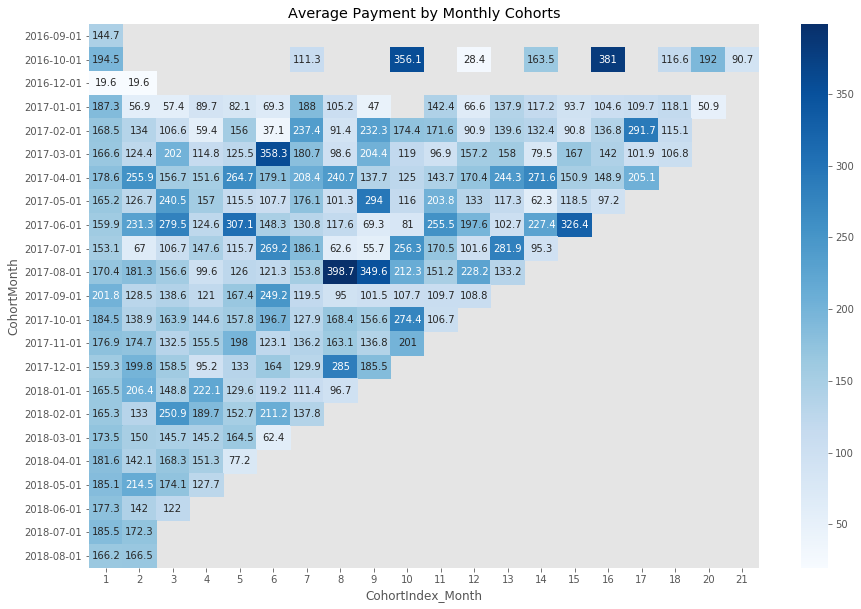

```python
# --- calculate average payment ---
# Calculate the average of the unit price column
monthly_cohort_payment = monthly_grouping['payment_value'].mean()

# Reset the index of cohort_data
monthly_cohort_payment = monthly_cohort_payment.reset_index()

# Create a pivot
monthly_average_payment = monthly_cohort_payment.pivot(index='CohortMonth',
                                                       columns='CohortIndex_Month',
                                                       values='payment_value')

# --- visualize average payment metric ---
# Initialize an 8 by 6 inches plot figure
plt.figure(figsize=(15, 10))

# Add a title
plt.title('Average Payment by Monthly Cohorts')

# Create the heatmap
sns.heatmap(monthly_average_payment.round(1), annot=True, cmap='Blues', fmt='g')
plt.show()
```

```python
# --- 8. RFM Analysis ---
# check the purchase period of Olist e-commerce dataset:
print('Min:{}; Max:{}'.format(min(olist_data_clean.order_purchase_date),
                              max(olist_data_clean.order_purchase_date)))

# create the snapshot_date: max_invoice_date + 1 day
snapshot_date = max(olist_data_clean.order_purchase_date) + timedelta(days=1)

# --- calculate RFM values  ---
# Calculate Recency, Frequency and Monetary value for each customer
rfm_datamart = olist_data_clean.groupby(['customer_id']).agg({
    'order_purchase_date': lambda x: (snapshot_date - x.max()).days,
    'order_id': 'count',
    'payment_value': 'sum'})

# Rename the columns
rfm_datamart.rename(columns={'order_purchase_date': 'Recency',
                             'order_id': 'Frequency',
                             'payment_value': 'MonetaryValue'}, inplace=True)

# Print top 5 rows
print(rfm_datamart.head())
```

```
Min:2016-09-04 00:00:00; Max:2018-09-03 00:00:00
                                  Recency  Frequency  MonetaryValue
customer_id
00012a2ce6f8dcda20d059ce98491703      294          1         114.74
000161a058600d5901f007fab4c27140      415          1          67.41
0001fd6190edaaf884bcaf3d49edf079      553          1         195.42
0002414f95344307404f0ace7a26f1d5      384          1         179.35
000379cdec625522490c315e70c7a9fb      155          1         107.01
```

```python
# --- calculate 3 groups for recency, frequency and MonetaryValue ---
# Create labels for Recency and Frequency
r_labels = range(3, 0, -1); f_labels = range(1, 4); m_labels = range(1, 4)

# Assign these labels to three equal percentile groups
r_groups = pd.qcut(rfm_datamart['Recency'], q=3, labels=r_labels)

# Assign these labels to custom pd.cut groups
f_groups = pd.cut(rfm_datamart['Frequency'], bins=3, labels=f_labels)
# Assign these labels to three equal percentile groups
# f_groups = pd.qcut(rfm_datamart['Frequency'], q=3, labels=f_labels)

# Assign these labels to three equal percentile groups
m_groups = pd.qcut(rfm_datamart['MonetaryValue'], q=3, labels=m_labels)

# Create new columns R and F
rfm_datamart = rfm_datamart.assign(R=r_groups.values, F=f_groups.values, M=m_groups.values)

# Print top 5 rows
print(rfm_datamart.head())
```

```
                                  Recency  Frequency  MonetaryValue  R  F  M
customer_id
00012a2ce6f8dcda20d059ce98491703      294          1         114.74  2  1  2
000161a058600d5901f007fab4c27140      415          1          67.41  1  1  1
0001fd6190edaaf884bcaf3d49edf079      553          1         195.42  1  1  3
0002414f95344307404f0ace7a26f1d5      384          1         179.35  1  1  3
000379cdec625522490c315e70c7a9fb      155          1         107.01  3  1  2
```

```python
# --- calculate RFM score ---
def join_rfm(x):
    ''' Concatenate RFM quartile values to RFM_Segment'''
    return str(x['R']) + str(x['F']) + str(x['M'])

# Concatenate RFM quartile values to RFM_Segment
rfm_datamart['RFM_Segment'] = rfm_datamart.apply(join_rfm, axis=1)

# Calculate RFM_Score
rfm_datamart['RFM_Score'] = rfm_datamart[['R','F','M']].sum(axis=1)
print(rfm_datamart['RFM_Score'].head())

# --- Find average monetary value for RFM score segment equals 9 ---
print(rfm_datamart[rfm_datamart.RFM_Score == 9].MonetaryValue.mean())

# --- analyzing customer groups per RFM_Score ---
rfm_score_agg = rfm_datamart.groupby('RFM_Score').agg({
    'Recency': 'mean',
    'Frequency': 'mean',

  	# Return the size of each segment
    'MonetaryValue': ['mean', 'count']
}).round(1)

print(rfm_score_agg)
```

```
customer_id
00012a2ce6f8dcda20d059ce98491703    5.0
000161a058600d5901f007fab4c27140    3.0
0001fd6190edaaf884bcaf3d49edf079    5.0
0002414f95344307404f0ace7a26f1d5    5.0
000379cdec625522490c315e70c7a9fb    6.0
Name: RFM_Score, dtype: float64
1333.8
          Recency Frequency MonetaryValue
             mean      mean          mean  count
RFM_Score
3.0         429.1       1.1          49.6  11022
4.0         328.2       1.1          79.9  22216
5.0         246.9       1.2         209.4  32177
6.0         155.2       1.2         270.8  22014
7.0          85.4       1.4         467.9  11232
8.0         114.5      16.8        2289.1      4
9.0         115.0      24.0        1333.8      1
```

```python
# --- creating custom segment labels ---
# Define rfm_level function
def rfm_level(df):
    ''' assign a custome segment label based on RFM score '''
    if df['RFM_Score'] >= 7:
        return '1_High'
    elif ((df['RFM_Score'] >= 5) and (df['RFM_Score'] < 7)):
        return '2_Medium'
    else:
        return '3_Low'

# Create a new variable RFM_Level
rfm_datamart['RFM_Level'] = rfm_datamart.apply(rfm_level, axis=1)

# Print top 5 rows
print(rfm_datamart.head())

# --- analyzing custom segments ---
# Calculate average values for each RFM_Level, and return a size of each segment
rfm_level_agg = rfm_datamart.groupby('RFM_Level').agg({
    'Recency': 'mean',
    'Frequency': 'mean',

  	# Return the size of each segment
    'MonetaryValue': ['mean', 'count']
}).round(1)

# Print the aggregated dataset
print(rfm_level_agg)
```

```
                                  Recency  Frequency  MonetaryValue  R  F  M  \
customer_id
00012a2ce6f8dcda20d059ce98491703      294          1         114.74  2  1  2
000161a058600d5901f007fab4c27140      415          1          67.41  1  1  1
0001fd6190edaaf884bcaf3d49edf079      553          1         195.42  1  1  3
0002414f95344307404f0ace7a26f1d5      384          1         179.35  1  1  3
000379cdec625522490c315e70c7a9fb      155          1         107.01  3  1  2

                                 RFM_Segment  RFM_Score RFM_Level
customer_id
00012a2ce6f8dcda20d059ce98491703         212        5.0  2_Medium
000161a058600d5901f007fab4c27140         111        3.0     3_Low
0001fd6190edaaf884bcaf3d49edf079         113        5.0  2_Medium
0002414f95344307404f0ace7a26f1d5         113        5.0  2_Medium
000379cdec625522490c315e70c7a9fb         312        6.0  2_Medium
          Recency Frequency MonetaryValue
             mean      mean          mean  count
RFM_Level
1_High       85.4       1.4         468.6  11237
2_Medium    209.7       1.2         234.3  54191
3_Low       361.7       1.1          69.9  33238
```

```
Recency          246.716062
Frequency          1.184988
MonetaryValue    205.599897
R                  2.002250
F                  1.000284
M                  1.999838
RFM_Segment             inf
RFM_Score          5.002372
dtype: float64
Recency          153.392938
Frequency          0.666062
MonetaryValue    620.579588
R                  0.816564
F                  0.020133
M                  0.816604
RFM_Score          1.162330
dtype: float64
            Recency     Frequency  MonetaryValue     RFM_Score
count  98666.000000  98666.000000   98666.000000  98666.000000
mean     246.716062      1.184988     205.599897      5.002372
std      153.392938      0.666062     620.579588      1.162330
min        1.000000      1.000000       6.150000      3.000000
25%      123.000000      1.000000      62.640000      4.000000
50%      228.000000      1.000000     109.500000      5.000000
75%      357.000000      1.000000     195.887500      6.000000
max      730.000000     34.000000  109312.640000      9.000000
```

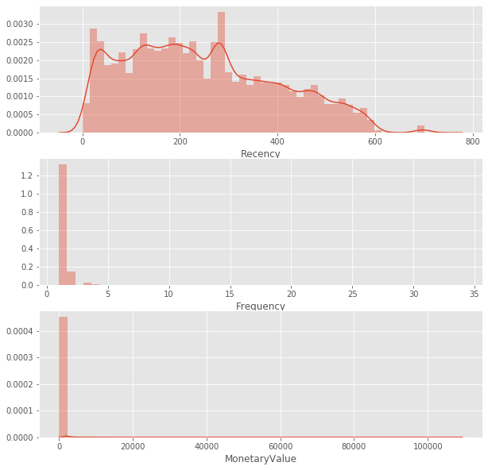

```python
# --- 9. Data Pre-Processing ---
# --- calculate statistics of variables  ---
# Print the average values of the variables in the dataset
print(rfm_datamart.mean())

# Print the standard deviation of the variables in the dataset
print(rfm_datamart.std())

# Get the key statistics of the dataset
print(rfm_datamart.describe())

# confirmed that no equal mean and variance on R-F-M segment(s)

# --- plot a series of histrograms on RFM variables ---
plt.figure(figsize=(10,10))

# Plot distribution of Recency
plt.subplot(3, 1, 1); sns.distplot(rfm_datamart['Recency'])

# Plot distribution of Frequency
plt.subplot(3, 1, 2); sns.distplot(rfm_datamart['Frequency'])

# Plot distribution of MonetaryValue
plt.subplot(3, 1, 3); sns.distplot(rfm_datamart['MonetaryValue'])

# Show the plot
plt.show()
```

```
        Recency  Frequency  MonetaryValue
count  98666.00   98666.00       98666.00
mean       0.00       0.00           0.00
std        1.00       1.00           1.00
min       -6.02      -0.35          -3.25
25%       -0.48      -0.35          -0.70
50%        0.23      -0.35          -0.09
75%        0.75      -0.35           0.55
max        1.57      11.43           7.51
```

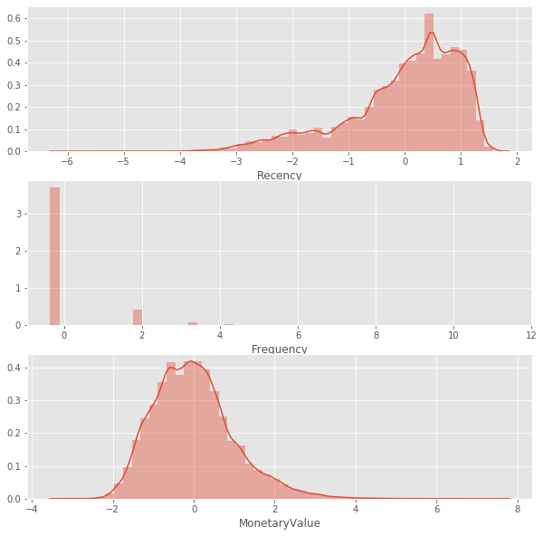

```python
# --- pre-process RFM data ---
# Unskew the datamart with log transform
rfm_datamart_log = np.log(rfm_datamart.iloc[:, 0:3])

# Initialize a scaler
scaler = StandardScaler()
scaler.fit(rfm_datamart_log)

# Scale and center the data
rfm_datamart_normalized = scaler.transform(rfm_datamart_log)

# Create a pandas DataFrame
rfm_datamart_normalized = pd.DataFrame(rfm_datamart_normalized, index=rfm_datamart_log.index, columns=rfm_datamart_log.columns)

# Print summary statistics
print(rfm_datamart_normalized.describe().round(2))

plt.figure(figsize=(10,10))

# --- plot a series of histrograms on normalized RFM variables ---
# Create a subplot of the distribution of Recency
plt.subplot(3, 1, 1); sns.distplot(rfm_datamart_normalized['Recency'])

# Create a subplot of the distribution of Frequency
plt.subplot(3, 1, 2); sns.distplot(rfm_datamart_normalized['Frequency'])

# Create a subplot of the distribution of MonetaryValue
plt.subplot(3, 1, 3); sns.distplot(rfm_datamart_normalized['MonetaryValue'])

# Show the plot
plt.show()
```

## Part 3 - DEVELOP

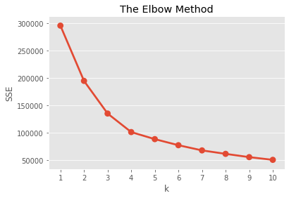

```python
# --- 10. K-Means Clustering --- #
# Initialize KMeans
kmeans = KMeans(n_clusters=3, random_state=1)

# Fit k-means clustering on the normalized data set
kmeans.fit(rfm_datamart_normalized)

# Extract cluster labels
cluster_labels = kmeans.labels_

# --- assign labels to raw data ---
# Create a DataFrame by adding a new cluster label column
rfm_datamart_k3 = rfm_datamart.assign(Cluster=cluster_labels)

# Group the data by cluster
grouped_clust_3 = rfm_datamart_k3.groupby(['Cluster'])

# Calculate average RFM values and segment sizes per cluster value
grouped_clust_3.agg({
    'Recency': 'mean',
    'Frequency': 'mean',
    'MonetaryValue': ['mean', 'count']
  }).round(1)

# --- calculate sum of squared errors ---
# Fit KMeans and calculate SSE for each k
sse = {}
for k in range(1, 11):

    # Initialize KMeans with k clusters
    kmeans = KMeans(n_clusters=k, random_state=1)

    # Fit fit on the normalized dataset
    kmeans.fit(rfm_datamart_normalized)

    # Assign sum of squared distances to k element of dictionary
    sse[k] = kmeans.inertia_

# --- plot sum of sqaured errors: elbow method ---
# Add the plot title "The Elbow Method"
plt.title('The Elbow Method')

# Add X-axis label "k"
plt.xlabel('k')

# Add Y-axis label "SSE"
plt.ylabel('SSE')

# Plot SSE values for each key in the dictionary
sns.pointplot(x=list(sse.keys()), y=list(sse.values()))
plt.show()
```

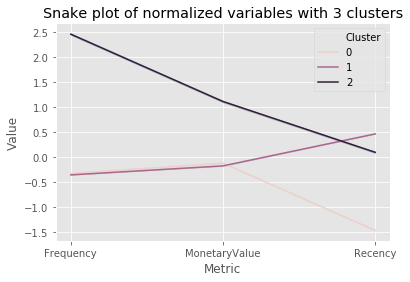

```python
# --- prepare data for the snake plot ---
rfm_datamart_normalized['Cluster'] = rfm_datamart_k3['Cluster']

# Melt the normalized dataset and reset the index
rfm_datamart_melt = pd.melt(rfm_datamart_normalized.reset_index(),
                    id_vars=['customer_id', 'Cluster'],
                    value_vars=['Recency', 'Frequency', 'MonetaryValue'],
                    var_name='Metric',
                    value_name='Value')

# --- visualize snake plot ---
# Add the plot title
plt.title('Snake plot of normalized variables with 3 clusters')

# Add the x axis label
plt.xlabel('Metric')

# Add the y axis label
plt.ylabel('Value')

# Plot a line for each value of the cluster variable
sns.lineplot(data=rfm_datamart_melt, x='Metric', y='Value', hue='Cluster')
plt.show()
```

```
         Recency  Frequency  MonetaryValue
Cluster
0          -0.74      -0.14          -0.23
1           0.24      -0.15          -0.29
2           0.04       1.09           1.97
```

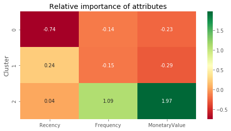

```python
# --- calculate relative importance of each attribute ---
# Calculate average RFM values for each cluster
avg_cluster = rfm_datamart_k3[['Recency','Frequency','MonetaryValue','Cluster']].groupby(['Cluster']).mean()

# Calculate average RFM values for the total customer population
avg_population = rfm_datamart_k3[['Recency','Frequency','MonetaryValue']].mean()

# Calculate relative importance of cluster's attribute value compared to population
relative_imp = (avg_cluster / avg_population) - 1

# Print relative importance scores rounded to 2 decimals
print(relative_imp.round(2))

# --- plot relative importance heatmap ---
# Initialize a plot with a figure size of 8 by 4 inches
plt.figure(figsize=(8, 4))

# Add the plot title
plt.title('Relative importance of attributes')

# Plot the heatmap
sns.heatmap(data=relative_imp, annot=True, fmt='.2f', cmap='RdYlGn')
plt.show()
```

```python
# --- built 4 clusters segmentation ---
olist_data_clean['order_purchase_date_2'] = olist_data_clean['order_purchase_date']

# Calculate Recency, Frequency, Monetary value and Tenure for each customer
rfmt_datamart = olist_data_clean.groupby(['customer_id']).agg({
    'order_purchase_date': lambda x: (snapshot_date - x.max()).days,
    'order_id': 'count',
    'payment_value': 'sum',
    'order_purchase_date_2': lambda x: (x.max() - x.min()).days})

# Rename the columns
rfmt_datamart.rename(columns={'order_purchase_date': 'Recency',
                              'order_id': 'Frequency',
                              'payment_value': 'MonetaryValue',
                              'order_purchase_date_2': 'Tenure'}, inplace=True)

# dealt with rows when Tenure == 0: replaced by 1
rfmt_datamart['Tenure'] = np.where(rfmt_datamart['Tenure'] == 0, 1, rfmt_datamart['Tenure'])

# apply log transform
rfmt_datamart_log = np.log(rfmt_datamart)

# apply feature scaler
scaler = StandardScaler()
scaler.fit(rfmt_datamart_log)

# Scale and center the data
rfmt_datamart_normalized = scaler.transform(rfmt_datamart_log)

# Create a pandas DataFrame
rfmt_datamart_normalized = pd.DataFrame(rfmt_datamart_normalized,
                                        index=rfmt_datamart_log.index,
                                        columns=rfmt_datamart_log.columns)

# Print top 5 rows
print(rfmt_datamart_normalized.head())
```

```
                                   Recency  Frequency  MonetaryValue  Tenure
customer_id
00012a2ce6f8dcda20d059ce98491703  0.525682  -0.354014      -0.034849     0.0
000161a058600d5901f007fab4c27140  0.922622  -0.354014      -0.619665     0.0
0001fd6190edaaf884bcaf3d49edf079  1.253209  -0.354014       0.550634     0.0
0002414f95344307404f0ace7a26f1d5  0.833220  -0.354014       0.456281     0.0
000379cdec625522490c315e70c7a9fb -0.211490  -0.354014      -0.111538     0.0
```

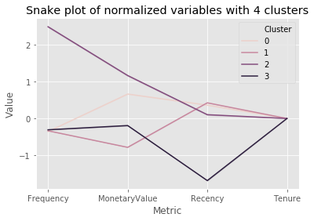

```python
# Re-initialize KMeans
kmeans = KMeans(n_clusters=4, random_state=1)

# Fit k-means clustering on the normalized data set
kmeans.fit(rfmt_datamart_normalized)

# Extract cluster labels
cluster_labels = kmeans.labels_

# --- analyze the segments ---
# Create a new DataFrame by adding a cluster label column to datamart_rfmt
rfm_datamart_k4 = rfmt_datamart.assign(Cluster=cluster_labels)

del(rfmt_datamart)

# Group by cluster
grouped_clust_4 = rfm_datamart_k4.groupby(['Cluster'])

# Calculate average RFMT values and segment sizes for each cluster
grouped_clust_4.agg({
    'Recency': 'mean',
    'Frequency': 'mean',
    'MonetaryValue': 'mean',
    'Tenure': ['mean', 'count']
  }).round(1)

# --- prepare data for the snake plot ---
rfmt_datamart_normalized['Cluster'] = rfm_datamart_k4['Cluster']

# Melt the normalized dataset and reset the index
rfmt_datamart_melt = pd.melt(rfmt_datamart_normalized.reset_index(),
                    id_vars=['customer_id', 'Cluster'],
                    value_vars=['Recency', 'Frequency', 'MonetaryValue', 'Tenure'],
                    var_name='Metric',
                    value_name='Value')

# --- visualize snake plot ---
# Add the plot title
plt.title('Snake plot of normalized variables with 4 clusters')

# Add the x axis label
plt.xlabel('Metric')

# Add the y axis label
plt.ylabel('Value')

# Plot a line for each value of the cluster variable
sns.lineplot(data=rfmt_datamart_melt, x='Metric', y='Value', hue='Cluster')
plt.show()
```

## Part 4 - DEPLOY

```python
# save model results as .csv file:
```